# Assignment 2

Jaxon Abercrombie

10/6/2021

### Data Wrangling

#### Read in the Data

```r
chsInd <- read.csv("chs_individual.csv")
chsReg <- read.csv("chs_regional.csv")
chsCombo <- smartbind(chsInd, chsReg)

# Check location variable to ensure no N/As
sum(is.na(chsCombo$townname))
```

```
## [1] 0
```

#### Q1

```r
# Check dimensions to ensure no duplicates
dim(chsInd)
```

```
## [1] 1200   23
```

```r
dim(chsReg)
```

```
## [1] 12 27
```

```r
dim(chsCombo)
```

```
## [1] 1212   49
```

```r
# The combo of the two data sets has the sum of the two row values from the dim() function
# To ensure there are not duplicates...
chsCombo <- unique(chsCombo)
chsCombo <- data.table(chsCombo)

# Impute values for those that are missing; to continuous variables only
chsMH <-
  chsCombo %>%
  filter (male == 1 & hispanic == 1)

chsCombo[is.na(agepft), agepft := mean(chsMH$agepft, na.rm = TRUE)]
chsCombo[is.na(height), height := mean(chsMH$height, na.rm = TRUE)]
chsCombo[is.na(weight), weight := mean(chsMH$weight, na.rm = TRUE)]
chsCombo[is.na(bmi), bmi := mean(chsMH$bmi, na.rm = TRUE)]
chsCombo[is.na(fev), fev := mean(chsMH$fev, na.rm = TRUE)]
chsCombo[is.na(fvc), fvc := mean(chsMH$fvc, na.rm = TRUE)]
chsCombo[is.na(mmef), mmef := mean(chsMH$mmef, na.rm = TRUE)]
chsCombo[is.na(educ_parent), educ_parent := mean(chsMH$educ_parent, na.rm = TRUE)]
chsCombo[is.na(male), male := round(mean(chsMH$male, na.rm = TRUE), 1)]
chsCombo[is.na(asthma), asthma := round(mean(chsMH$asthma, na.rm = TRUE), 1)]
chsCombo[is.na(smoke), smoke := round(mean(chsMH$smoke, na.rm = TRUE), 1)]
chsCombo[is.na(gasstove), gasstove := round(mean(chsMH$educ_parent, na.rm = TRUE), 1)]
```

#### Q2

```r
# BMI; Numerical to categorical
chsCombo$bmiCat <- cut(chsCombo$bmi,
                       breaks = c(0,14,22,24,Inf),
                       labels = c("underweight", "normal", "overweight", "obese"))

# Ensure coding is correct by viewing range of values within each BMI category
chsCombo %>%
  group_by(bmiCat) %>%
  summarize(
    min = min(bmi),
    max = max(bmi),
    count = n()
  )
```

```
## # A tibble: 4 x 4
##   bmiCat        min   max count
##   <fct>       <dbl> <dbl> <int>
## 1 underweight  11.3  14.0    35
## 2 normal       14.0  22.0   987
## 3 overweight   22.0  24.0    87
## 4 obese        24.0  41.3   103
```

#### Q3

```r
# Some values of gasstove are 2, which would create NAs in our smoke_gas_exposure variable
# This is corrected by adding the "| 2" in our code to allow 1 or 2 to be for gasstove
# Create smoke and gas exposure variable, ensuring the 4 different combinations are taken care of
chsCombo <-
  chsCombo %>%
  mutate(smoke_gas_exposure = case_when(smoke == 0 & gasstove == 0 ~ "neither",
                                        smoke == 1 & gasstove == 0 ~ "smoke only",
                                        smoke == 0 & gasstove == 1 ~ "gas stove only",
                                        smoke == 0 & gasstove == 2 ~ "gas stove only",
                                        smoke == 1 & gasstove == 1 ~ "both",
                                        smoke == 1 & gasstove == 2 ~ "both"))

# Check to see that there are 4 distinct categories and that they match the above code
table(chsCombo$smoke_gas_exposure)
```

```
##
##           both gas stove only        neither     smoke only
##            154            803            219             36
```

```r
sum(is.na(chsCombo$smoke_gas_exposure))
```

```
## [1] 0
```

#### Q4

```r
# By town
chsCombo %>%
  group_by(townname) %>%
  summarize(count = n(),
          meanFEV = mean(fev),
          sdFEV = sd(fev),
          percAsthma = 100*mean(asthma, na.rm = TRUE),
          sdAsthma = sd(asthma, na.rm = TRUE))
```

```
## # A tibble: 12 x 6
##    townname      count meanFEV sdFEV percAsthma sdAsthma
##    <chr>         <int>   <dbl> <dbl>      <dbl>    <dbl>
##  1 Alpine          101   2091.  289.       10.9    0.313
##  2 Atascadero      101   2082.  322.       24.8    0.434
##  3 Lake Elsinore   101   2048.  302.       11.9    0.325
##  4 Lake Gregory    101   2095.  317.       14.9    0.357
##  5 Lancaster       101   2018.  317.       15.8    0.367
##  6 Lompoc          101   2046.  349.       10.9    0.313
##  7 Long Beach      101   1995.  319.       12.9    0.337
##  8 Mira Loma       101   1995.  325.       14.9    0.357
##  9 Riverside       101   1999.  278.       10.9    0.313
## 10 San Dimas       101   2031.  317.       16.8    0.376
## 11 Santa Maria     101   2034.  311.       12.9    0.337
## 12 Upland          101   2036.  342.       11.9    0.325
```

```r
# By sex
chsCombo <- chsCombo %>%
  mutate(sex = factor(male,
                      levels = c(0,1),
                      labels = c("male","female")))

chsCombo %>%
  group_by(sex) %>%
  summarize(count = n(),
          meanFEV = mean(fev),
          sdFEV = sd(fev),
          percAsthma = 100*mean(asthma, na.rm = TRUE),
          sdAsthma = sd(asthma, na.rm = TRUE))
```

```
## # A tibble: 2 x 6
##   sex    count meanFEV sdFEV percAsthma sdAsthma
##   <fct>  <int>   <dbl> <dbl>      <dbl>    <dbl>
## 1 male     610   1974.  315.       11.8    0.323
## 2 female   602   2105.  304.       16.4    0.371
```

```r
# By obesity level
chsCombo %>%
  group_by(bmiCat) %>%
  summarize(count = n(),
          meanFEV = mean(fev),
          sdFEV = sd(fev),
          percAsthma = 100*mean(asthma, na.rm = TRUE),
          sdAsthma = sd(asthma, na.rm = TRUE))
```

```
## # A tibble: 4 x 6
##   bmiCat      count meanFEV sdFEV percAsthma sdAsthma
##   <fct>       <int>   <dbl> <dbl>      <dbl>    <dbl>
## 1 underweight    35   1699.  305.       8.57    0.284
## 2 normal        987   2011.  295.      13.5     0.342
## 3 overweight     87   2224.  317.      16.1     0.370
## 4 obese         103   2268.  324.      20.4     0.405
```

```r
# By smoke and gas exposure
chsCombo %>%
  group_by(smoke_gas_exposure) %>%
  summarize(count = n(),
          meanFEV = mean(fev, na.rm = TRUE),
          sdFEV = sd(fev, na.rm = TRUE),
          percAsthma = 100*mean(asthma, na.rm = TRUE),
          sdAsthma = sd(asthma, na.rm = TRUE))
```

```
## # A tibble: 4 x 6
##   smoke_gas_exposure count meanFEV sdFEV percAsthma sdAsthma
##   <chr>              <int>   <dbl> <dbl>      <dbl>    <dbl>
## 1 both                 154   2034.  301.       12.3    0.330
## 2 gas stove only       803   2031.  318.       14.3    0.351
## 3 neither              219   2066.  328.       14.2    0.349
## 4 smoke only            36   2077.  294.       16.7    0.378
```

### Looking at the Data (EDA)

The primary questions of interest are:

1. What is the association between BMI and FEV (forced expiratory volume)?
2. What is the association between smoke and gas exposure and FEV?
3. What is the association between PM2.5 exposure and FEV?

**Check Data**

```r
dim(chsCombo)
```

```
## [1] 1212   52
```

**Check Variables**

```r
str(chsCombo)
```

```
## Classes 'data.table' and 'data.frame':   1212 obs. of  52 variables:
##  $ sid               : int  1 2 6 7 8 10 13 16 19 21 ...
##  $ townname          : chr  "Lancaster" "Lancaster" "Lancaster" "Lancaster" ...
##  $ male              : int  1 1 0 0 0 1 1 0 0 0 ...
##  $ race              : chr  "W" "W" "B" "O" ...
##  $ hispanic          : int  0 0 0 0 1 1 1 0 0 1 ...
##  $ agepft            : num  10.15 10.46 10.1 10.75 9.78 ...
##  $ height            : int  123 145 145 156 132 138 140 141 138 126 ...
##  $ weight            : int  54 77 143 72 61 82 79 74 82 59 ...
##  $ bmi               : num  16.2 16.6 30.9 13.4 15.9 ...
##  $ asthma            : int  0 0 0 0 0 0 0 1 0 0 ...
##  $ active_asthma     : int  0 0 0 0 0 1 0 0 0 0 ...
##  $ father_asthma     : int  0 0 0 NA 1 1 0 0 0 0 ...
##  $ mother_asthma     : int  0 0 0 0 0 0 0 1 0 0 ...
##  $ wheeze            : int  0 1 0 1 1 0 0 1 0 0 ...
```

[output cut: 39 more lines]

```r
summary(chsCombo)
```

```
##       sid           townname              male            race
##  Min.   :   1.0   Length:1212        Min.   :0.0000   Length:1212
##  1st Qu.: 528.8   Class :character   1st Qu.:0.0000   Class :character
##  Median :1041.5   Mode  :character   Median :0.0000   Mode  :character
##  Mean   :1037.5                      Mean   :0.4967
##  3rd Qu.:1554.2                      3rd Qu.:1.0000
##  Max.   :2053.0                      Max.   :1.0000
##  NA's   :12
##     hispanic          agepft           height          weight
##  Min.   :0.0000   Min.   : 8.961   Min.   :114.0   Min.   : 42.00
##  1st Qu.:0.0000   1st Qu.: 9.634   1st Qu.:135.0   1st Qu.: 66.00
##  Median :0.0000   Median : 9.952   Median :138.0   Median : 76.00
##  Mean   :0.4342   Mean   : 9.927   Mean   :138.9   Mean   : 79.55
##  3rd Qu.:1.0000   3rd Qu.:10.149   3rd Qu.:143.0   3rd Qu.: 87.00
##  Max.   :1.0000   Max.   :12.731   Max.   :165.0   Max.   :207.00
##  NA's   :12
##       bmi            asthma       active_asthma  father_asthma
##  Min.   :11.30   Min.   :0.0000   Min.   :0.00   Min.   :0.00000
##  1st Qu.:15.96   1st Qu.:0.0000   1st Qu.:0.00   1st Qu.:0.00000
##  Median :17.85   Median :0.0000   Median :0.00   Median :0.00000
##  Mean   :18.58   Mean   :0.1411   Mean   :0.19   Mean   :0.08318
##  3rd Qu.:19.94   3rd Qu.:0.0000   3rd Qu.:0.00   3rd Qu.:0.00000
##  Max.   :41.27   Max.   :1.0000   Max.   :1.00   Max.   :1.00000
##                                   NA's   :12     NA's   :118
##  mother_asthma        wheeze          hayfever         allergy
##  Min.   :0.0000   Min.   :0.0000   Min.   :0.0000   Min.   :0.0000
##  1st Qu.:0.0000   1st Qu.:0.0000   1st Qu.:0.0000   1st Qu.:0.0000
##  Median :0.0000   Median :0.0000   Median :0.0000   Median :0.0000
##  Mean   :0.1023   Mean   :0.3313   Mean   :0.1747   Mean   :0.2929
##  3rd Qu.:0.0000   3rd Qu.:1.0000   3rd Qu.:0.0000   3rd Qu.:1.0000
##  Max.   :1.0000   Max.   :1.0000   Max.   :1.0000   Max.   :1.0000
##  NA's   :68       NA's   :83       NA's   :130      NA's   :75
##   educ_parent        smoke             pets           gasstove
##  Min.   :1.000   Min.   :0.0000   Min.   :0.0000   Min.   :0.0000
##  1st Qu.:2.000   1st Qu.:0.0000   1st Qu.:1.0000   1st Qu.:1.0000
##  Median :3.000   Median :0.0000   Median :1.0000   Median :1.0000
##  Mean   :2.747   Mean   :0.1568   Mean   :0.7667   Mean   :0.8267
##  3rd Qu.:3.000   3rd Qu.:0.0000   3rd Qu.:1.0000   3rd Qu.:1.0000
##  Max.   :5.000   Max.   :1.0000   Max.   :1.0000   Max.   :2.0000
##                                   NA's   :12
```

[output cut: 49 more lines]

```
##  Min.   :0.760   Min.   :1.090   Min.   : 1.520   Min.   :-120.7
##  1st Qu.:1.835   1st Qu.:2.978   1st Qu.: 4.930   1st Qu.:-118.8
##  Median :2.825   Median :4.135   Median : 6.370   Median :-117.7
##  Mean   :2.788   Mean   :4.342   Mean   : 6.708   Mean   :-118.3
##  3rd Qu.:3.817   3rd Qu.:5.982   3rd Qu.: 9.395   3rd Qu.:-117.4
##  Max.   :4.620   Max.   :7.400   Max.   :11.430   Max.   :-116.8
##  NA's   :1200    NA's   :1200    NA's   :1200     NA's   :1200
##       lat                bmiCat    smoke_gas_exposure     sex
##  Min.   :32.84   underweight: 35   Length:1212        male  :610
##  1st Qu.:33.93   normal     :987   Class :character   female:602
##  Median :34.10   overweight : 87   Mode  :character
##  Mean   :34.20   obese      :103
##  3rd Qu.:34.65
##  Max.   :35.49
##  NA's   :1200
```

Unlike last assignment, there are no negative minimum values that need to be dealt with. Though there are variables with NAs after the binding of the two data sets, they are within variables that are not used in the analysis of the three questions above. For that, we will keep them as is for now.

**Check Variables More Closely**

```r
# summary() for numerical, table() for categorical
summary(chsCombo$bmi)
```

```
##    Min. 1st Qu.  Median    Mean 3rd Qu.    Max.
##   11.30   15.96   17.85   18.58   19.94   41.27
```

```r
summary(chsCombo$fev)
```

```
##    Min. 1st Qu.  Median    Mean 3rd Qu.    Max.
##   984.8  1829.8  2063.9  2039.1  2222.1  3323.7
```

```r
table(chsCombo$smoke_gas_exposure)
```

```
##
##           both gas stove only        neither     smoke only
##            154            803            219             36
```

```r
summary(chsCombo$pm25_mass)
```

```
##    Min. 1st Qu.  Median    Mean 3rd Qu.    Max.    NA's
##   5.960   7.615  10.545  14.362  20.988  29.970    1200
```

After looking more closely at the variables, each seems adequate with min, max, and other values. However, pm25_mass has 1200 missing values, since the chsInd data set did not provide any data for the variable pm25_mass. We can acknowledge that averaging 12 sites may not be representative to apply to 1200 instances, and since we only are using leaflet() and discovering an association, we can just use the 12 and see how it goes.

**Q1**

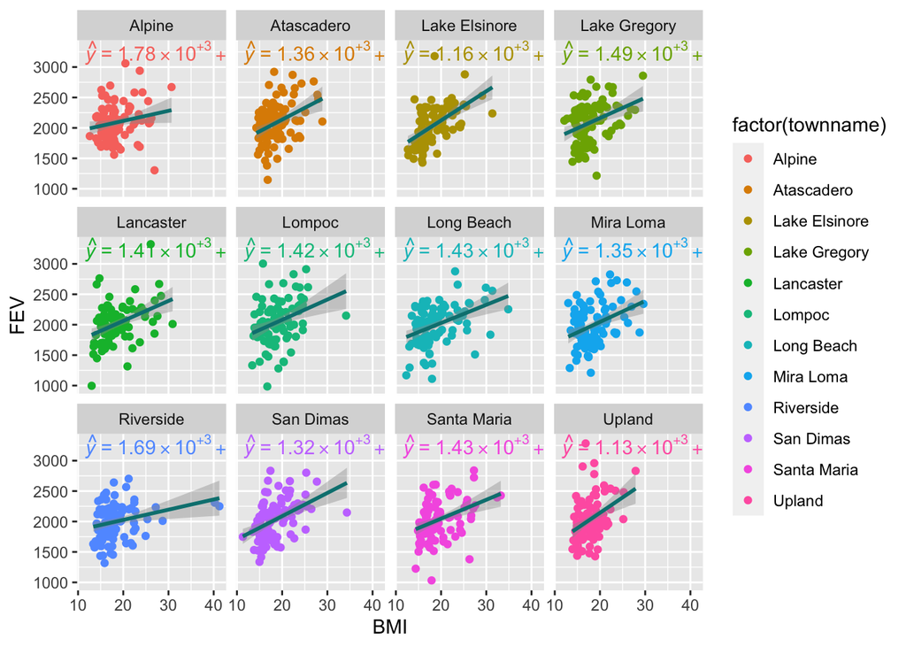

```r
chsCombo %>%
  ggplot(mapping = aes(x = bmi, y = fev, color = factor(townname))) +
  geom_point() +
  geom_smooth(method = "lm", color = "#008080") +
  stat_poly_eq(formula = y ~ x,
               eq.with.lhs = "italic(hat(y))~`=`~",
               aes(label = paste(..eq.label.., ..rr.label.., sep = "~~~")),
               label.y = 1000,
               parse = TRUE) +
  labs(x = "BMI", y = "FEV") +
  facet_wrap(~ factor(townname))
```

Based on the many scatter plots created, there is a clear relationship that an increase in BMI is associated with an increase in FEV. Of course, some towns experience a stronger association and some weaker. Though the linear association is not visible by points alone, the added linear regression lines appear to add more understanding of the data and the positive relationship involved.

**Q2**

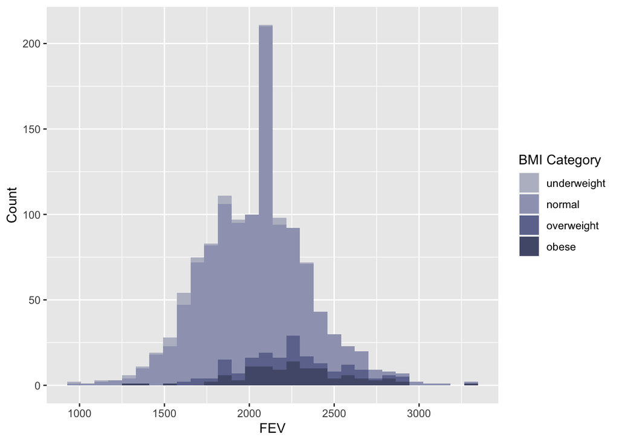

```r
chsCombo %>%
  ggplot(aes(x = fev, fill = bmiCat)) +
  geom_histogram() +
  scale_fill_manual(values = c("#B9BCCB","#9EA3BD","#6D759C","#535979")) +
  labs(x = "FEV", y = "Count", fill = "BMI Category")
```

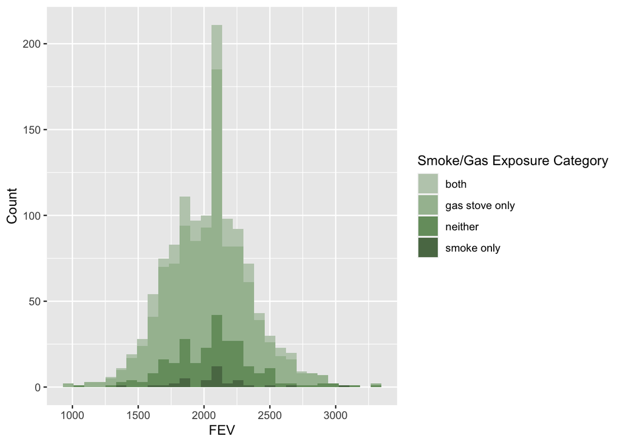

```r
chsCombo %>%
  ggplot(aes(x = fev, fill = smoke_gas_exposure)) +
  geom_histogram() +
  scale_fill_manual(values = c("#BDCCBA","#A5BD9F","#769C6D","#5A7853")) +
  labs(x = "FEV", y = "Count", fill = "Smoke/Gas Exposure Category")
```

Based on the stacked histogram for BMI category, it is clear that the overweight and obese categories tend to have higher FEV, though they also have the greatest variance across X. Additionally, the plot demonstrates that normal BMI is the most abundant category of the 4. Normal BMI is generally normally distributed for FEV, but it has a clear outlier bin around 2100, which may just be a standard/common value for FEV.

**Q3**

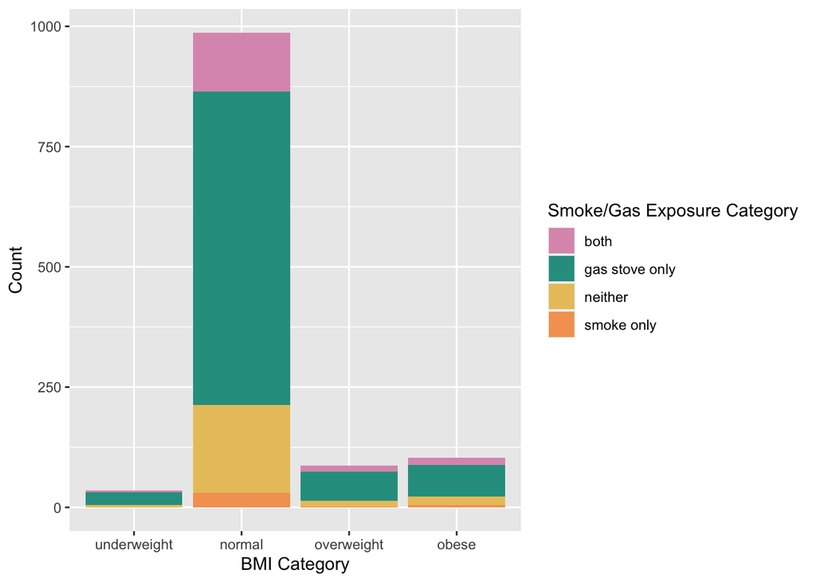

```r
chsCombo %>%
  ggplot(aes(x = bmiCat, fill = smoke_gas_exposure)) +
  geom_bar() +
  scale_fill_manual(values = c("#DD99BB","#2A9D8F","#E9C46A","#F4A261")) +
  labs(x = "BMI Category", y = "Count", fill = "Smoke/Gas Exposure Category")
```

**Q4**

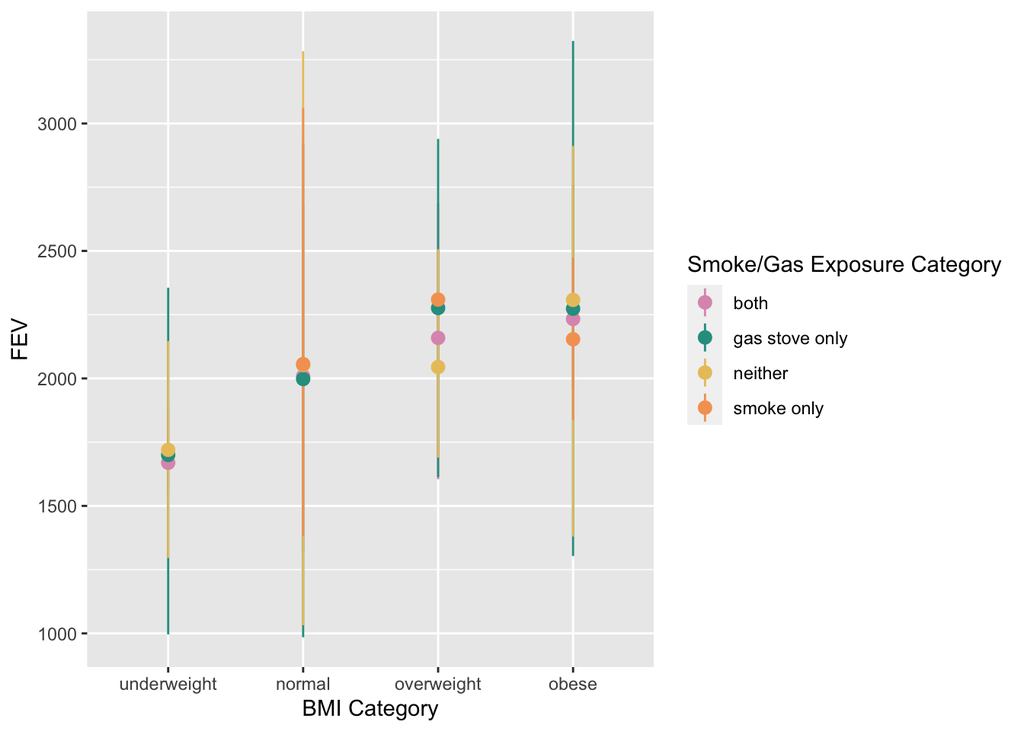

```r
chsCombo %>%
  ggplot() +
  stat_summary(aes(x = bmiCat, y = fev,
             group = smoke_gas_exposure,
             color = smoke_gas_exposure),
             fun = mean,
             fun.max = max,
             fun.min = min) +
  scale_color_manual(values = c("#DD99BB","#2A9D8F","#E9C46A","#F4A261")) +
  labs(x = "BMI Category", y = "FEV", color = "Smoke/Gas Exposure Category")
```

The statistic summary graph for BMI category provides an abundance of information. The lines extending from each plotted average of FEV indicate the minimum and maximum FEV values for each BMI category. In most cases, it appears that the “gas stove only” category experiences the greatest variation in FEV, for its ranges are the largest among the 4 types. The average values of FEV for each category are fairly close to one another, with the “overweight” BMI category demonstrating the greatest differences in means. Furthermore, no particular smoke/gas exposure category appears to be the consistent largest or smallest across BMI category.

**Q5**

```r
temp.pal <- colorFactor(palette ='Set3', domain=chsCombo$pm25_mass)

leaflet(chsCombo[!is.na(pm25_mass)]) %>%
  addProviderTiles('CartoDB.Positron') %>%
  addCircles(
    lat = ~lat, lng=~lon,
    label = chsCombo$townname, color = ~ temp.pal(pm25_mass),
    opacity = .9, fillOpacity = .9, radius = 800) %>%
  addLegend('bottomleft', pal = temp.pal, values = chsCombo$pm25_mass,
          title = 'PM25 Concentration', opacity = 1)
```

[interactive chart not shown]

This plot gives more insight into geographic location of towns as PM2.5 differs. The lowest PM2.5 values appear closest to Santa Barbara and its neighboring towns. On the other hand, the greatest PM2.5 values appear closest to Los Angeles and the surrounding area.

**Q6**

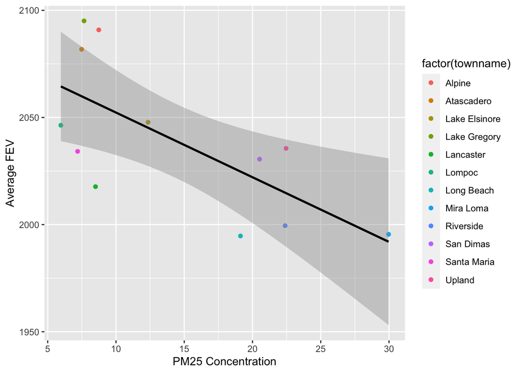

```r
chsCombo6 <-
  chsCombo %>%
  group_by(townname) %>%
  mutate(fev = mean(fev))

chsCombo6 %>%
  ggplot(mapping = aes(x = pm25_mass, y = fev, color = factor(townname))) +
  geom_point() +
  geom_smooth(method = "lm", color = "black") +
  labs(x = "PM25 Concentration", y = "Average FEV")
```

This last plot provides the mean of FEV for each town and each town’s PM2.5 concentration. Based on the regression line provided on the plot, it appears that an increase in PM2.5 concentration is associated with a decrease in FEV. While there are certainly larger residuals than others (Lake Gregory, Alpine) and some smaller than others (Mira Loma, Lake Elsinore), the points follow a generally linear pattern. Because of that, it seems evident that the negative correlation exists between the variables FEV and PM2.5.

### Overall Question Answers

1. What is the association between BMI and FEV (forced expiratory volume)?

   If someone has a higher BMI, they are more likely to have a higher FEV value.
2. What is the association between smoke and gas exposure and FEV?